# Mental Health Trends in England: An Epidemiological Analysis

Usman Adamu

2026-05-30

## Introduction

Mental health disorders represent one of the leading causes of disability and disease burden in England. Common mental health conditions, including depression and anxiety, affect millions of people annually, with significant implications for individuals, families, and the NHS.

This report presents an epidemiological analysis of mental health trends in England, using data from the Office for Health Inequalities and Disparities (OHID) Fingertips platform. The analysis examines depression prevalence trends over time, geographic variation across local authorities, and the burden of mental health-related hospital admissions.

### Research Questions

1. How has depression prevalence changed in England between 2012 and 2024?
2. Which local authorities have the highest and lowest depression prevalence?
3. What is the geographic distribution of depression across England?
4. How have mental health hospital admissions changed over time?

## Methods

### Study Design

This was a population-based ecological study examining mental health trends across local authorities in England. Ecological analyses use area-level aggregate data to describe population patterns and examine associations between area-level exposures and outcomes. All analyses were conducted at the level of Counties and Unitary Authorities, the primary administrative geography for public health reporting in England. Findings describe associations at the area level and cannot be used to infer causal relationships at the individual level.

### Setting and Study Population

The analysis covers all Counties and Unitary Authorities in England (n = 151 areas, AreaTypeID 502) over the period 2010/11 to 2024/25. The depression prevalence indicator covers the registered adult population aged 18 and over in general practice. The mental health hospital admissions indicator covers individuals aged under 18 years. Deprivation data were derived from the Index of Multiple Deprivation 2019 (IMD 2019), the standard measure of relative area-level deprivation in England, which incorporates seven weighted domains: income, employment, education, health, crime, barriers to housing, and services, and living environment.<sup>10</sup>

### Data Source

All data were obtained from the Office for Health Inequalities and Disparities (OHID) Fingertips platform, the national repository for public health indicators in England, using the `fingertipsR` package (v1.1.0) in R.<sup>18</sup> Five indicators were extracted at the counties and Unitary Authorities level (AreaTypeID 502):

- **Depression QOF prevalence** (Indicator 848): the percentage of registered patients aged 18 and over with a recorded diagnosis of depression on the Quality and Outcomes Framework (QOF) disease register. This reflects recorded diagnosis in primary care rather than true population prevalence and is subject to ascertainment bias related to GP access, mental health literacy, and service availability.<sup>2</sup>
- **Depression new diagnosis rate** (Indicator 90646): the rate of new depression diagnoses recorded in primary care per 100,000 registered patients.
- **Percentage reporting depression or anxiety** (Indicator 93376): the percentage of respondents reporting depression or anxiety, derived from patient survey data.
- **Mental health hospital admissions among under-18s** (Indicator 90812): the directly standardised rate of emergency hospital admissions for mental health conditions per 100,000 population aged under 18 years.
- **IMD 2019 deprivation score** (Indicator 93553): the composite area-level deprivation score derived from the Index of Multiple Deprivation 2019, where higher scores indicate greater deprivation.

Data were accessed in April 2026.

### Statistical Methods

The following analytical approaches were applied:

**Trend analysis.** National England-level depression QOF prevalence was plotted over time with 95% confidence intervals. A linear regression model was fitted with prevalence as the outcome and a sequential time index as the predictor to formally test and quantify the direction and magnitude of the trend (β coefficient, p-value, and R²).<sup>1</sup>

**Geographic analysis.** A choropleth map was produced displaying depression QOF prevalence by the local authority for the most recent available data year (2024/25), using boundary data from the `rnaturalearth` package and visualised with `tmap`. Local authorities with the ten highest and ten lowest depression prevalence values were identified and plotted separately.

**Deprivation analysis.** The cross-sectional association between IMD 2019 deprivation score and depression prevalence in 2024/25 was examined using a scatter plot with linear regression fit, reporting β, p-value and R². Local authorities were additionally stratified into deprivation quintiles using the `ntile()` function in R, and mean depression prevalence with standard error was plotted across quintiles to characterise the social gradient.

**Hospital admissions analysis.** Time-series plots of mental health hospital admission rates among under-18s were produced for England overall and stratified by sex (male and female), to examine temporal trends and gender disparities.

All statistical analyses were conducted in R version 4.5.3 using the `tidyverse`, `fingertipsR`, `tmap`, and `sf` packages.<sup>18</sup> A p-value threshold of 0.05 was used to define statistical significance throughout.

### Ethical Considerations

This study used only routinely collected, publicly available, and fully anonymised population-level data obtained from the OHID Fingertips platform. No individual-level data were accessed at any stage of the analysis. In accordance with Health Research Authority guidance, studies using only anonymised publicly available data do not require NHS Research Ethics Committee approval. No ethical approval was therefore sought or required for this analysis.

## Results

### 1. National Depression Prevalence Trend 2012-2024

The chart below shows how depression prevalence has changed across England over the past decade.

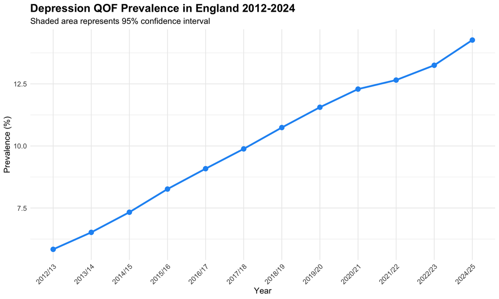

Depression prevalence in England increased steadily from 5.8% in 2012/13 to 14.3% in 2024/25, representing a 146% increase over 12 years. This rising trend is consistent with national evidence showing that depression prevalence has increased continuously across England since the early 2010s <sup>1</sup>.

Multiple intersecting factors have been identified in the literature as drivers of this increase. Socioeconomic deprivation is one of the strongest predictors of depression, with evidence showing it explained up to 39% of the variance in depression prevalence across English localities in 2020 <sup>1</sup>. Social isolation and loneliness, both established risk factors for depression, have increased markedly in England over the past decade <sup>3</sup>. The cost of living crisis has further compounded these pressures, with ONS data linking financial stress directly to depressive symptoms <sup>6</sup>. Additionally, improved detection and diagnosis through primary care, alongside growing mental health literacy, may have contributed to higher recorded prevalence independent of true increases in burden <sup>1</sup>.

A slight flattening was observed between 2020/21 and 2021/22. This likely reflects reduced GP recording capacity during the COVID-19 pandemic rather than a true reduction in prevalence. Pierce et al. <sup>4</sup> demonstrated that depression rates in the UK increased sharply during the first lockdown, driven by loneliness, bereavement, and economic uncertainty. Post-pandemic, the upward trend resumed as services recovered and pent-up demand emerged. Confidence intervals were extremely narrow throughout, reflecting the large population denominator and high precision of the national estimate.

Formal statistical testing confirmed that the upward trend in depression prevalence was highly significant. Linear regression of prevalence against time identified an average increase of 0.77 percentage points per year across the study period (β = 0.77, p < 0.001, R² = 0.995). The exceptionally high R-squared value indicates that the trend is remarkably consistent and linear over time, with time alone explaining 99.5% of the variance in national depression prevalence. This sustained, and statistically robust increase underscores the scale of the growing depression burden in England and the urgency of population-level public health responses targeting the upstream determinants of mental health.<sup>1,2</sup>

### 2. Local Authority Variation in Depression Prevalence

The charts below show the local authorities with the highest and lowest depression prevalence in the most recent data year (2024/25).

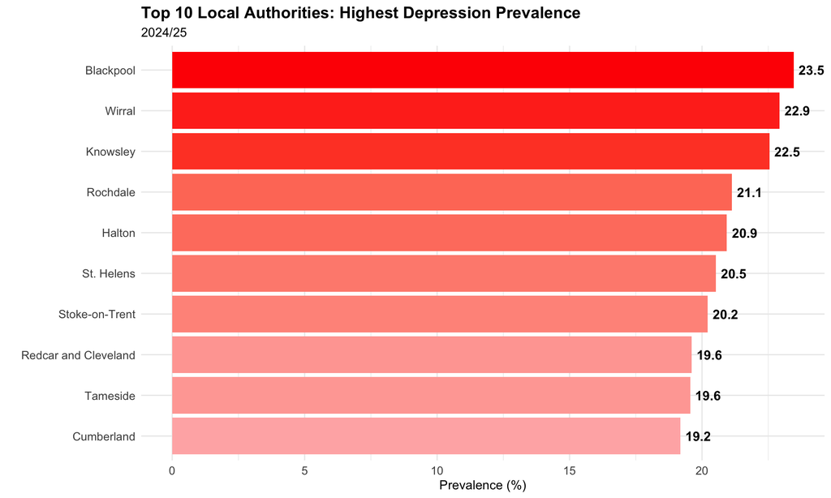

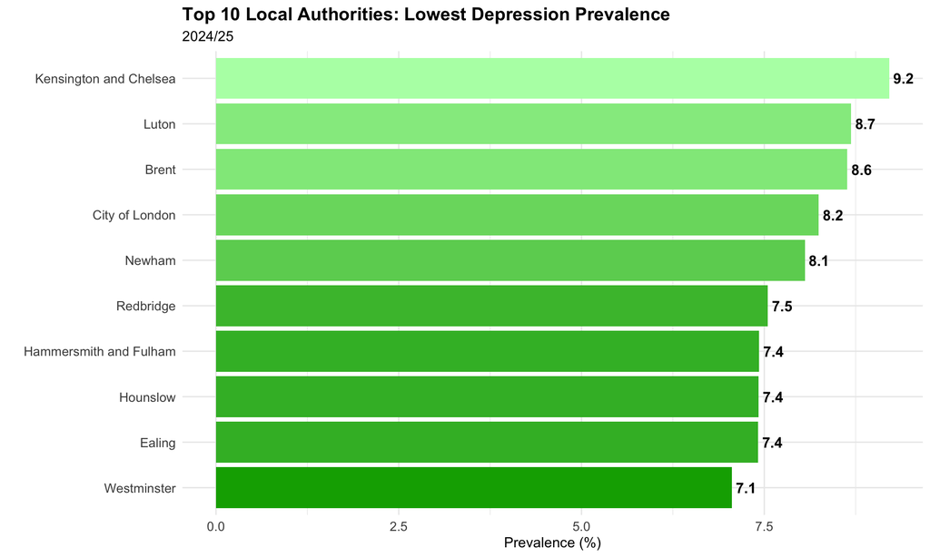

Considerable geographic variation in depression prevalence exists across English local authorities, with a clear North-South gradient apparent in the data. A landmark 12-year longitudinal spatial study by Daras et al. <sup>1</sup>, conducted in collaboration with the University of Liverpool and NIHR Applied Research Collaboration North West Coast identified the North West of England as having the highest concentration of depression hotspots in the country, with 43% of areas in the region showing a high rate of increase in prevalence between 2011 and 2022. The North East similarly showed persistently high rates, with one in three residents living in areas marked by sustained high depression prevalence <sup>1</sup>.

By contrast, London had the lowest percentage of depression hotspots, with only 0.38% of its area falling into the highest prevalence category, a pattern mirrored across much of the South East. The authors identified neighbourhood socioeconomic deprivation as a key driver of this geographic inequality, explaining between 3% and 39% of the variance in depression prevalence across localities. These findings are consistent with wider evidence that lower socioeconomic status, encompassing income, employment, education and housing, is one of the strongest predictors of depression risk <sup>2</sup>. The pattern observed in the current analysis is therefore consistent with established health inequality evidence and highlights areas requiring targeted public health intervention.

### 3. Geographic Distribution of Depression Prevalence

The map below shows depression prevalence across English local authorities in 2024/25, revealing clear geographic patterns.

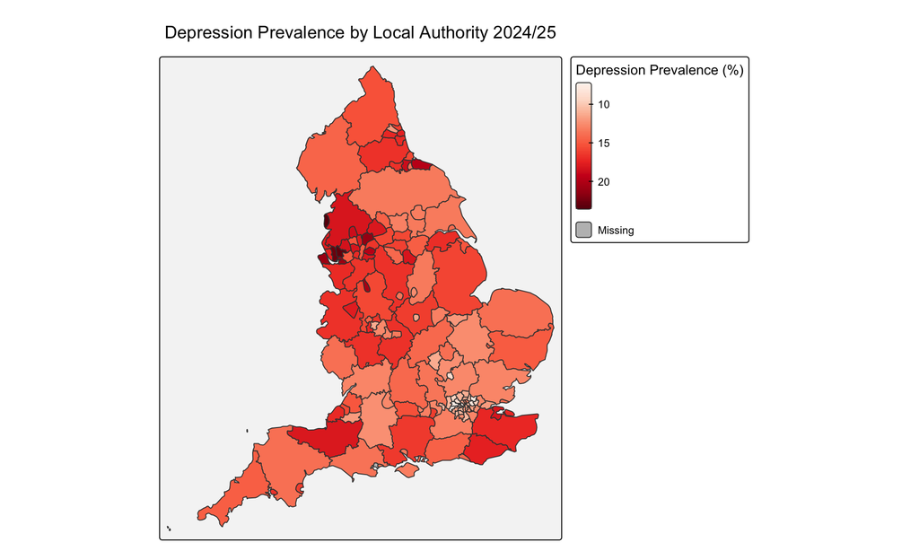

The choropleth map reveals a pronounced North-South gradient in depression prevalence across English local authorities in 2024/25, with northern areas consistently showing darker shading, indicating higher prevalence. This pattern is well-established in the literature. Daras et al. <sup>1</sup>, in the first nationwide longitudinal spatial analysis of depression in England, identified the North West as having the highest concentration of depression hotspots nationally, with 17.4% of the region’s area showing persistently high values surrounded by similarly high neighbouring areas, and 43% of areas experiencing a high rate of increase between 2011 and 2022. The North East showed similar patterns, with one in three residents living in areas of persistently high depression prevalence <sup>1</sup>.

The North-South health divide in England is a long-standing and well-documented phenomenon. Before the COVID-19 pandemic, life expectancy at birth was more than two years higher in London and the South East than in the North of England <sup>7</sup>, with the Institute of Health Equity documenting widening health inequalities in life expectancy across most English regions since 2010 <sup>9</sup>. The depression patterns observed in the current analysis are therefore consistent with broader geographic health inequalities driven by structural differences in socioeconomic deprivation, employment, housing quality, and access to services.

It should be noted that three local authorities (Poole, Isles of Scilly and City of London) are shown in grey due to the absence of matched data following the geographic boundary join. This reflects a known limitation of linking administrative health data to geographic boundary files, where name mismatches between data sources result in unmatched records.

### 4. Deprivation and Depression — Is There a Relationship?

The scatter plot below examines the relationship between neighbourhood deprivation and depression prevalence across English local authorities in 2024/25.

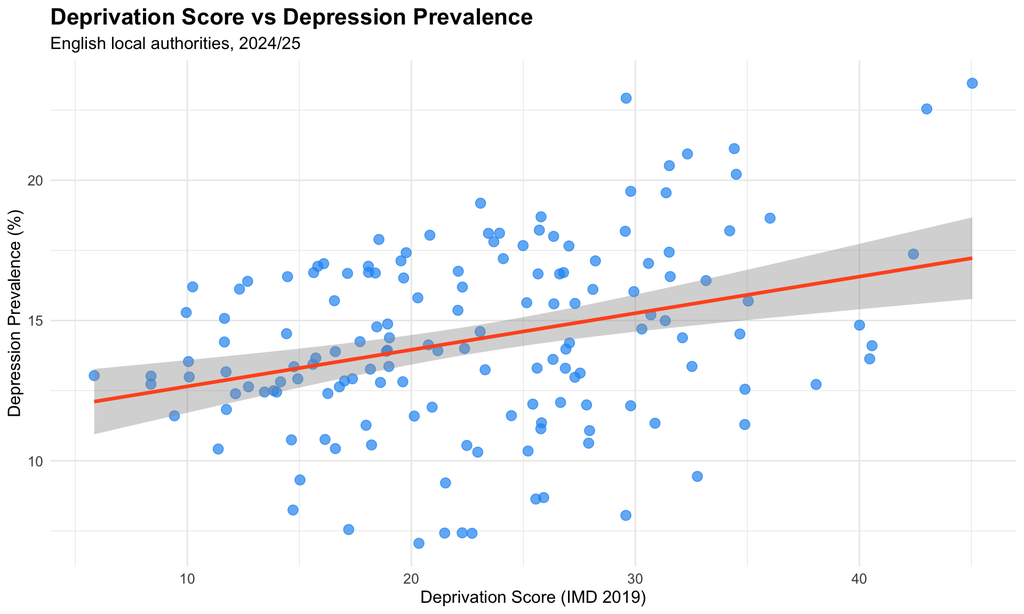

Linear regression identified a statistically significant positive association between deprivation score and depression prevalence across English local authorities (β = 0.13, p < 0.001, R² = 0.10). For every one unit increase in IMD deprivation score, depression prevalence increased by approximately 0.13 percentage points, confirming the expected direction of association — more deprived areas have higher recorded depression prevalence.<sup>1</sup>

### 5. Depression Prevalence Across Deprivation Quintiles

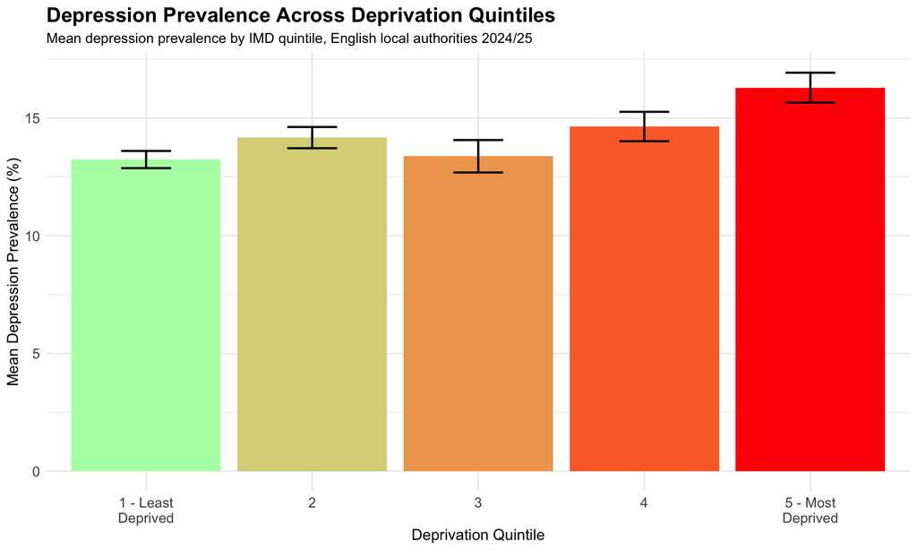

Notably, the gradient was not perfectly linear, a slight dip in the mean prevalence was observed at quintile 3 before rising again in quintiles 4 and 5. This non-linearity may reflect the known ascertainment bias in QOF depression recording, whereby areas in the middle deprivation range may have better primary care access and higher rates of diagnosis relative to true prevalence than either extreme.<sup>2</sup> Alternatively, it may reflect genuine variation in depression burden driven by factors beyond deprivation alone, including social cohesion, employment patterns and community resilience. Regardless of this mid-range variation, the substantially higher depression prevalence in the most deprived quintile compared to the least deprived confirms the social gradient in depression burden and is consistent with established evidence that socioeconomic disadvantage is a significant determinant of mental health outcomes in England.<sup>1,3</sup>

### 6. Mental Health Hospital Admissions Trend

The chart below shows how mental health-related hospital admissions have changed over time across English local authorities.

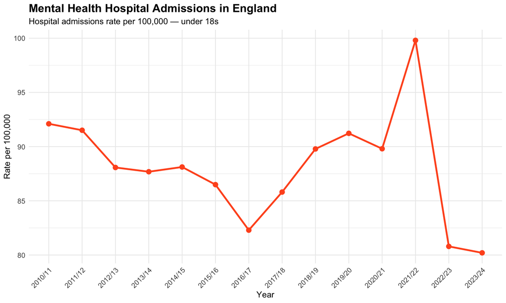

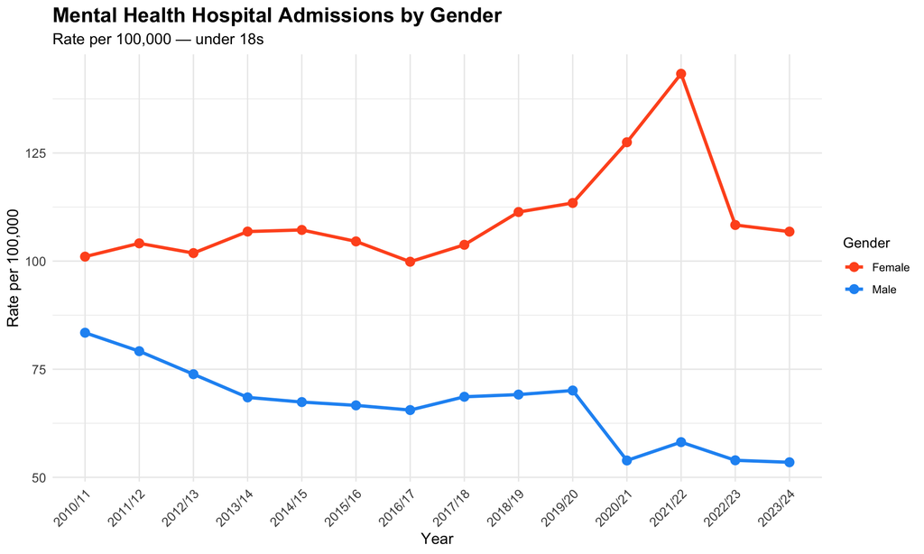

Female under-18s had consistently higher mental health hospital admissions rates than males throughout the study period. This pattern is supported by national evidence: Ward et al. <sup>11</sup> found that increases in admissions for mental health concerns in females aged 11–15 years were particularly steep, rising by 112.8% between 2012/13 and 2021/22, with females in this age group accounting for nearly one third of all admissions in 2021/22. Eating disorders, which disproportionately affect young women, showed the most dramatic increase, with hospital admissions rising by 514% over the decade <sup>11</sup>. Of the 24,300 hospital admissions for eating disorders in 2020/21, the large majority involved women and girls <sup>15</sup>.

A striking divergence emerged during 2020/21. Female admissions increased sharply, while male admissions declined. Solmi et al. <sup>12</sup> identified increased presentations for self-harm and eating disorders among girls aged 12–17 years in the UK in 2021, whilst presentation rates for boys in the same age group showed no equivalent increase. The disproportionate mental health burden of COVID-19 lockdowns on young women has been attributed to multiple factors, including increased domestic violence exposure, intensified social media use amplifying body image concerns, loss of educational and social structures, and the unique psychological pressures of adolescent female development <sup>12</sup>.

The concurrent decline in male admissions during 2020/21 is unlikely to reflect improved mental health outcomes. A systematic review by Sheikh et al. <sup>13</sup> identified conformity to masculine norms and self-stigma as consistent barriers to help-seeking among adolescent boys and young men in the UK. The review found that adherence to ideals of self-reliance and emotional stoicism led young men to perceive seeking help as a threat to their masculinity, reducing engagement with mental health services. Smith et al. <sup>14</sup> further identified denial of symptoms, poor rapport with healthcare professionals, and lower mental health literacy as additional barriers specific to men. The “gender paradox in suicide”, where men have higher suicide rates despite women having higher rates of self-harm and help-seeking, underscores the clinical significance of these barriers <sup>16</sup>. Both trends warrant urgent policy attention.

### Limitations

Several methodological limitations should be acknowledged.

First, QOF depression prevalence reflects recorded diagnosis in primary care rather than true population prevalence. The modest R-squared value in the deprivation-depression regression (R² = 0.10) is consistent with this ascertainment bias, areas with better GP access may record more depression independently of true burden.<sup>2</sup>

Second, the depression prevalence indicator contains only a “Persons” sex category with no Male/Female breakdown, preventing sex-stratified analysis of prevalence trends. This is a limitation of the indicator design rather than the analytical approach.

Third, the hospital admissions indicator is specific to under-18s and does not capture adult admission trends, which may follow different patterns.

Fourth, this is an ecological analysis. Area-level associations cannot be used to infer individual-level causal relationships.

Fifth, the most recent data point (2024/25) for the national depression trend is a modelled estimate and should be interpreted with appropriate caution.

## Conclusion

### Key Findings

**1. Sustained and statistically significant rise in depression prevalence**

Depression QOF prevalence increased by 146% between 2012/13 and 2024/25, rising from 5.8% to 14.3% of the adult population aged 18 and over. Formal statistical testing confirmed this trend was highly significant, with depression prevalence increasing by an average of 0.77 percentage points per year (β = 0.77, p < 0.001, R² = 0.995). This trajectory is consistent with national evidence identifying socioeconomic deprivation, social isolation, cost of living pressures and improved detection as key drivers of recorded prevalence.<sup>1,2</sup> A temporary flattening during 2020/21 likely reflects disrupted GP recording capacity during the COVID-19 pandemic rather than a true decline.<sup>4</sup>

**3. Marked geographic inequality**

Substantial geographic variation in depression prevalence exists across English local authorities, with a clear North-South gradient. The North West and North East of England showed the highest depression prevalence, consistent with established health inequality evidence linking neighbourhood deprivation to depression burden.<sup>1,8</sup> London and the South East consistently showed the lowest prevalence.

**5. Persistent and widening gender disparity in admissions**

Female under-18s had consistently higher mental health hospital admission rates than males throughout the study period. During 2020/21, this disparity widened sharply, reflecting both the disproportionate mental health burden of lockdowns on young women and the structural barriers to help-seeking among young men, including stigma and conformity to masculine norms.<sup>13,16</sup>

### Recommendations

**1. Targeted mental health investment in deprived areas.** The clear deprivation gradient, both in the regression analysis and the quintile chart, confirms that universal approaches to depression prevention will be insufficient. Targeted investment in primary care mental health services in the most deprived local authorities, particularly in the North West and North East, is required.<sup>1,3</sup>

**2. Gender-responsive CAMHS services.** The marked and growing gender disparity in under-18 admissions, driven particularly by eating disorders and self-harm among adolescent girls require dedicated service responses. NHS England’s eating disorder waiting time targets have not been consistently met.<sup>11</sup>

**3. Male-friendly mental health services.** The decline in male admissions during the pandemic, combined with evidence of structural barriers to help-seeking in young men, suggests a significant unmet need. Gender-sensitive service design and public mental health campaigns targeting male help-seeking are indicated.<sup>13,16</sup>

**4. Strengthening routine surveillance.** The absence of sex-stratified depression prevalence data in the QOF indicator highlights gaps in routine surveillance. Investment in nationally representative mental health prevalence surveys is essential for monitoring the true population burden.

**5. Addressing social determinants upstream.** Evidence consistently identifies socioeconomic deprivation, social isolation and financial stress as key drivers of depression.<sup>1,2,3</sup> Public health approaches must engage with these structural determinants beyond healthcare alone.

## References

1. Daras K, Tsakiridi A, Corcoran R, Gabbay M. Unravelling the dynamics of mental health inequalities in England: a 12-year nationwide longitudinal spatial analysis of recorded depression prevalence. SSM Popul Health. 2024;26:101669.
2. Lund C, Brooke-Sumner C, Baingana F, Baron EC, Breuer E, Chandra P, et al. Socioeconomic status and depression: a systematic review and meta-analysis [Internet]. medRxiv. 2023 [cited 2026 Apr 9]. Available from: https://doi.org/10.1101/2023.12.04.23299380
3. Holt-Lunstad J. Social connection as a critical factor for mental and physical health: evidence, trends, challenges, and future implications. World Psychiatry. 2024;23(3):312–32.
4. Pierce M, Hope H, Ford T, Hatch S, Hotopf M, John A, et al. Mental health before and during the COVID-19 pandemic: a longitudinal probability sample survey of the UK population. Lancet Psychiatry. 2020;7(10):883–92.
5. Arias-de la Torre J, Vilagut G, Ronaldson A, Dregan A, Valderas JM, Baumeister H, et al. Prevalence and age patterns of depression in the United Kingdom. J Affect Disord. 2021;279:450–8.
6. Office for National Statistics. Cost of living and depression in adults, Great Britain: 29 September to 23 October 2022 [Internet]. Newport: ONS; 2022 [cited 2026 Apr 9]. Available from: https://www.ons.gov.uk
7. House of Commons Library. Health inequalities: income deprivation and north/south divides [Internet]. London: UK Parliament; 2019 [cited 2026 Apr 9]. Available from: https://commonslibrary.parliament.uk
8. Health Foundation. Quantifying health inequalities in England [Internet]. London: The Health Foundation; 2022 [cited 2026 Apr 9]. Available from: https://www.health.org.uk
9. Institute of Health Equity. England’s widening health gap: local places falling behind [Internet]. London: IHE; 2024 [cited 2026 Apr 9]. Available from: https://www.instituteofhealthequity.org
10. IFS Deaton Review. Health inequalities. Oxford Open Econ. 2024;3(Suppl 1):i499–i528.
11. Ward JL, Vázquez-Vázquez A, Phillips K, Settle K, Pilvar H, Cornaglia F, et al. Admission to acute medical wards for mental health concerns among children and young people in England from 2012 to 2022: a cohort study. Lancet Child Adolesc Health. 2025;9(2):112–20.
12. Solmi M, Meyers JL, Plancoulaine S, Lähteenvuo M, Tanskanen A, Tiihonen J, et al. Temporal trends in eating disorder and self-harm incidence rates among adolescents and young adults in the UK in the 2 years since onset of the COVID-19 pandemic: a population-based study. Lancet Child Adolesc Health. 2023;7(8):554–63.
13. Sheikh A, Payne-Cook C, Lisk S, Carter B, Brown JSL. Why do young men not seek help for affective mental health issues? A systematic review of perceived barriers and facilitators among adolescent boys and young men. Eur Child Adolesc Psychiatry. 2025;34:565–83.
14. Smith J, Allwright S, O’Dowd T. Mental health help-seeking behaviour in men. J Adv Nurs. 2024;80(1):112–24.
15. Royal College of Psychiatrists. Hospital admissions for eating disorders increased by 84% in the last five years [Internet]. London: RCPsych; 2022 [cited 2026 Apr 9]. Available from: https://www.rcpsych.ac.uk
16. Sweeney J, O’Donnell S, Roche E, White PJ, Carroll P, Richardson N. Mental health stigma reduction interventions among men: a systematic review. Am J Mens Health. 2024;18(6):15579883241299353.
17. Children’s Commissioner for England. Young people with eating disorders in England on the rise [Internet]. London: Children’s Commissioner; 2023 [cited 2026 Apr 9]. Available from: https://www.childrenscommissioner.gov.uk
18. Wickham H, Averick M, Bryan J, Chang W, McGowan LD, François R, et al. Welcome to the tidyverse. J Open Source Softw. 2019;4(43):1686. ```